# TRENDY v15 - CO2 Fertilisation, Climate Effect and ELUC (Global)

18 September 2026

# 1. Introduction

This script reads global-total simulation output (S0-S6) for each TRENDY model from Trendyv15-v1.1.xlsx, and derives two alternative methods for each of three attribution terms:

| Term | Method 1 | Method 2 |
| --- | --- | --- |
| CO2 fertilisation | S1 - S0 | S3 - S6 (dL_CO2 not included for now) |
| Climate effect | S2 - S1 + S0 | S3 - S5 + S0 (dL_CLIM not included for now) |
| ELUC | S3 - S2 | S4 - S0 |

- **SLAND Method 1** = S2
- **SLAND Method 2** = S3 - S4 + S0 + dL (positive dL is a flux to atmosphere)

where **dL** is a correction term from Pierre’s Nature paper (see `3c. Read dL data`), applied only to Method 2. dL data is available from 1959 onwards; years before 1959 are treated as dL = 0 (i.e. no correction), not as missing data, so SLAND Method 2 remains defined across the full historical period.

A **third SLAND method** is available only for the handful of models that have delivered an “RSS” correction (see O’Sullivan et al. 2026, the updated land sink paper): `SLAND Method 3 = S2 - RSS`. Because only a subset of models currently deliver RSS, Method 3 is shown on the **individual-model plots only** (Sections 5 and 5b) - it is deliberately excluded from the all-model multi-model mean and decadal summary (Section 7), which stay restricted to Methods 1 and 2 so that every model contributing to those averages is on an equal footing. Section 7.1 is the deliberate exception: it restricts to the RSS-delivering models only, so all three methods can be compared directly on that smaller, equal-footing subset.

# 2. Configuration - file path, simulations

```r
# ---- EDIT THIS if the file lives somewhere else ----
xlsx_path <- "Trendyv15-v1.1.xlsx"

sims <- paste0("S", 0:6)

# Sheets are named "S0-Globe", "S1-Globe", ... "S6-Globe". Each is a WIDE
# table: one "year" column, then one column per model, plus (from S1
# onwards) a pre-computed "MME" column which we ignore since we calculate
# our own multi-model mean later. Using these sheets avoids the per-model
# sheets, whose "Year"/"year" column-name capitalisation is inconsistent.
sim_sheets <- paste0(sims, "-Globe")

stopifnot(all(sim_sheets %in% excel_sheets(xlsx_path)))
```

# 3. Read global totals for every model x simulation

```r
# Column headers are inconsistent between sheets in small ways (e.g.
# "LPJ-ml ", "LPJml ", "LPJml" all refer to the same model, with stray
# trailing spaces). This normalises a header to a clean model name.
clean_name <- function(x) {
  x <- str_trim(x)
  x <- str_replace(x, "^LPJ-?ml$", "LPJml")
  x
}

# Columns that are not actual models and should be dropped if present.
non_model_cols <- c("year", "MME", "sigma", "SIGMA")

read_globe_sheet <- function(sim) {
  sheet_name <- paste0(sim, "-Globe")

  # Read with all-text first so stray footer/summary rows (e.g. "Drift
  # (GtC/yr/100yr)", "2010s", "Key Numbers for ESSD") don't break numeric
  # parsing; we filter to genuine numeric-year rows below.
  raw <- read_excel(xlsx_path, sheet = sheet_name, col_types = "text")

  names(raw) <- clean_name(names(raw))
  names(raw)[str_to_lower(names(raw)) == "year"] <- "year"

  model_cols <- setdiff(names(raw), non_model_cols)

  raw |>
    mutate(year_num = suppressWarnings(as.numeric(year))) |>
    filter(!is.na(year_num)) |>
    transmute(
      Year = as.integer(year_num),
      across(all_of(model_cols), ~ suppressWarnings(as.numeric(.x)))
    ) |>
    pivot_longer(cols = all_of(model_cols),
                 names_to = "Model", values_to = "Global") |>
    mutate(Sim = sim, .after = Model)
}

raw_long <- map(sims, read_globe_sheet) |>
  list_rbind() |>
  select(Year, Model, Sim, Global) %>%
  subset(Model != "...25" & Model != "...26")

models <- sort(unique(raw_long$Model))
models
```

```
##  [1] "CABLE-POP" "CLASSIC"   "CLM-FATES" "CLM6.0"    "DLEM"      "E3SM"
##  [7] "EDv3"      "GDSTEM"    "IBIS"      "iMAPLE"    "IQJ"       "ISAM"
## [13] "JSBACH"    "JULES"     "LPJ-EOSIM" "LPJ-GUESS" "LPJml"     "LPX"
## [19] "Orchidee"  "SDGVM"     "VISIT"     "VISIT-UT"
```

```r
# Treat blank as missing data. A value of exactly 0 is ambiguous: it can
# either be an undelivered placeholder, or a genuine flux value (e.g. VISIT
# S0 2000 is a real 0, confirmed by its North/Tropics/South regional values
# summing to ~0). We distinguish the two using the fact that an
# *undelivered* model-simulation has EVERY year set to 0/blank, whereas a
# *delivered* series is only occasionally, if ever, exactly 0.
#
# Rule: within each Model x Sim series, if ALL non-missing values are 0,
# the whole series is treated as not-yet-delivered (-> NA). Otherwise,
# any individual 0 values are kept as genuine data.
raw_long <- raw_long |>
  group_by(Model, Sim) |>
  mutate(
    all_zero_or_na = all(is.na(Global) | Global == 0),
    Global = if_else(all_zero_or_na, NA_real_, Global)
  ) |>
  ungroup() |>
  select(-all_zero_or_na)

glimpse(raw_long)
```

```
## Rows: 50,204
## Columns: 4
## $ Year   <int> 1700, 1700, 1700, 1700, 1700, 1700, 1700, 1700, 1700, 1700, 170…
## $ Model  <chr> "CABLE-POP", "CLASSIC", "CLM6.0", "CLM-FATES", "DLEM", "E3SM", …
## $ Sim    <chr> "S0", "S0", "S0", "S0", "S0", "S0", "S0", "S0", "S0", "S0", "S0…
## $ Global <dbl> 0.5062418, 0.0000000, 0.1382982, 0.0000000, 0.0000000, 0.988626…
```

# 3b. Read RSS land-sink correction data (for SLAND Method 3)

```r
# ---- EDIT THIS if the file lives somewhere else ----
rss_path <- "GCB2026_RSS_global.csv"

# RSS model names sometimes differ from the TRENDY workbook's model names
# - either a different naming convention for the same model (e.g.
# "JULES-ES" vs "JULES", "ORCHIDEE" vs "Orchidee", "LPJmL" vs "LPJml"), or
# a genuinely different label for the same underlying model (e.g. "E3SM"
# is the same model the workbook calls "ELM" - the E3SM Land Model).
# This maps every RSS column name onto the canonical model name used
# elsewhere in this script. Any RSS model NOT in this map (currently
# "IQJ" and "ISBA-CTRIP") has no corresponding S0-S6 data in the TRENDY
# workbook either, so there is nothing for it to correct - those columns
# are dropped, with a message noting so.
rss_name_map <- c(
  "CABLE-POP" = "CABLE-POP", "CLASSIC"   = "CLASSIC",  "CLM6.0"    = "CLM6.0",
  "CLM-FATES" = "CLM-FATES", "DLEM"      = "DLEM",      "E3SM"      = "E3SM",
  "EDv3"      = "ED",        "ELM-FATES" = "ELM-FATES", "GDSTEM"    = "GDSTEM",
  "IBIS"      = "IBIS",      "iMAPLE"    = "iMAPLE",    "ISAM"      = "ISAM",
  "IQJ" = "IQJ",
  "JSBACH"    = "JSBACH",    "JULES"  = "JULES",     "LPJ-EOSIM" = "LPJ-EOSIM",
  "LPJ-GUESS" = "LPJ-GUESS", "LPJmL"     = "LPJml",     "LPX-Bern"  = "LPX",
  "ORCHIDEE"  = "Orchidee",  "SDGVM"     = "SDGVM",     "VISIT"     = "VISIT",
  "VISIT-UT"  = "VISIT-UT"
)

rss_raw <- read_csv(rss_path, show_col_types = FALSE) |>
  rename(Year = 1)

rss_long_raw <- rss_raw |>
  pivot_longer(-Year, names_to = "Model_RSS", values_to = "RSS")

unmapped_rss_models <- setdiff(unique(rss_long_raw$Model_RSS), names(rss_name_map))
if (length(unmapped_rss_models) > 0) {
  message("RSS columns with no matching TRENDY workbook model (dropped): ",
          paste(unmapped_rss_models, collapse = ", "))
}

rss_long <- rss_long_raw |>
  filter(Model_RSS %in% names(rss_name_map)) |>
  mutate(Model = unname(rss_name_map[Model_RSS]), .after = Model_RSS) |>
  select(Year, Model, RSS)

# Same "all zero/blank in a series = not yet delivered" convention as the
# main workbook data (Section 3).
rss_long <- rss_long |>
  group_by(Model) |>
  mutate(
    all_zero_or_na = all(is.na(RSS) | RSS == 0),
    RSS = if_else(all_zero_or_na, NA_real_, RSS)
  ) |>
  ungroup() |>
  select(-all_zero_or_na)

# Models currently delivering the RSS correction
rss_models <- rss_long |>
  filter(!is.na(RSS)) |>
  distinct(Model) |>
  arrange(Model) |>
  pull(Model)

rss_models
```

```
## [1] "CABLE-POP" "CLASSIC"   "GDSTEM"    "IBIS"      "JSBACH"    "VISIT"
## [7] "iMAPLE"
```

# 3c. Read dL data

```r
dL_path <- "dL_Pierre_Nature_paper.csv"

dL_raw <- read_csv(dL_path, show_col_types = FALSE) |>
  mutate(Year = as.integer(Year))

stopifnot(all(c("Year", "dL") %in% names(dL_raw)))

# dL only covers 1959 onwards. Years before that are treated as 0 (per
# instructions), not missing, so SLAND Method 2 doesn't turn NA for the
# entire pre-1959 period. Any gap from 1959 onwards is left as a
# genuine NA rather than silently filled, so it propagates correctly
# if there's an actual data gap later on.
dL <- tibble(Year = min(raw_long$Year, na.rm = TRUE):max(raw_long$Year, na.rm = TRUE)) |>
  left_join(dL_raw, by = "Year") |>
  mutate(dL = if_else(is.na(dL) & Year < 1959, 0, dL))
```

# 4. Derive CO2 fertilisation, Climate effect, ELUC and SLAND

```r
wide <- raw_long |>
  pivot_wider(names_from = Sim, values_from = Global)

derived <- wide |>
  left_join(dL, by = "Year") |>
  mutate(
    CO2fert_M1  = S1 - S0,
    CO2fert_M2  = S3 - S6,
    Climate_M1  = S2 - S1 + S0,
    Climate_M2  = S3 - S5 + S0,
    ELUC_M1     = S3 - S2,
    ELUC_M2     = S4 - S0,
    # SLAND = CO2 fertilisation + Climate effect, for each method
    SLAND_M1    = S2,
    SLAND_M2    = S3 - S4 + S0 + dL
  ) |>
  select(Year, Model, CO2fert_M1, CO2fert_M2,
         Climate_M1, Climate_M2, ELUC_M1, ELUC_M2,
         SLAND_M1, SLAND_M2)

derived_long <- derived |>
  pivot_longer(
    cols = -c(Year, Model),
    names_to = c("Variable", "Method"),
    names_pattern = "^(.*)_(M[12])$",
    values_to = "Value"
  ) |>
  filter(!is.na(Value)) |>
  mutate(
    Variable = recode(Variable,
                       CO2fert  = "CO2 fertilisation",
                       Climate  = "Climate effect",
                       ELUC     = "ELUC",
                       SLAND    = "SLAND"),
    Method = recode(Method,
                     M1 = "Method 1",
                     M2 = "Method 2")
  )

# SLAND Method 3: S2 - RSS, only for models with a delivered RSS
# correction. This is intentionally NOT added to derived_long/derived
# above, so it never enters the multi-model mean or decadal table
# (Sections 6-7) - only the individual-model plots (Sections 5, 5b).
sland_m3 <- wide |>
  select(Year, Model, S2) |>
  inner_join(rss_long, by = c("Year", "Model")) |>
  filter(!is.na(S2), !is.na(RSS)) |>
  transmute(Year, Model,
            Variable = "SLAND",
            Method = "Method 3 (RSS-corrected)",
            Value = S2 - RSS)

# Combined dataset for individual-model plots only: Methods 1 & 2 for
# every variable, PLUS Method 3 for SLAND where RSS data exists.
extended_long <- bind_rows(derived_long, sland_m3)

# # Which models actually contribute data to each variable/method?
# extended_long |>
#   distinct(Variable, Method, Model) |>
#   mutate(
#     Variable = factor(Variable, levels = c("CO2 fertilisation", "Climate effect", "ELUC", "SLAND")),
#     Method = factor(Method, levels = c("Method 1", "Method 2", "Method 3 (RSS-corrected)")),
#     contributes = "x"
#   ) |>
#   arrange(Variable, Method) |>
#   pivot_wider(id_cols = Model, names_from = c(Variable, Method),
#               values_from = contributes, names_sep = " - ", values_fill = "") |>
#   arrange(Model) |>
#   kable(caption = "Models currently contributing to each term/method") |>
#   kable_styling(full_width = FALSE) |>
#   scroll_box(width = "100%")
```

# 5. Time series - individual models

Note: SLAND includes a third line (Method 3, RSS-corrected) where a model has delivered the RSS correction - see Section 3b.

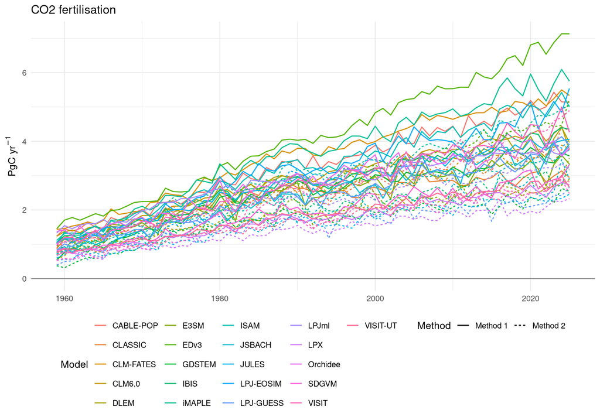

```r
start_plot = 1959

plot_variable <- function(var_name) {
  d <- extended_long |> filter(Variable == var_name & Year >= start_plot)

  ggplot(d, aes(x = Year, y = Value, colour = Model, linetype = Method)) +
    geom_line(linewidth = 0.6) +
    geom_hline(yintercept = 0, colour = "grey40", linewidth = 0.3) +
    labs(title = var_name,
         y = expression(PgC~yr^-1), x = NULL,
         colour = "Model", linetype = "Method") +
    theme_minimal(base_size = 12) +
    theme(legend.position = "bottom")
}

plot_variable("CO2 fertilisation")
```

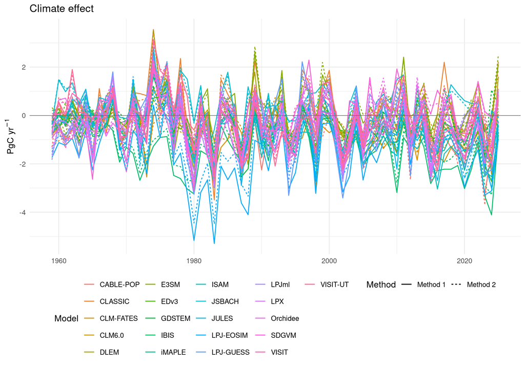

```r
plot_variable("Climate effect")
```

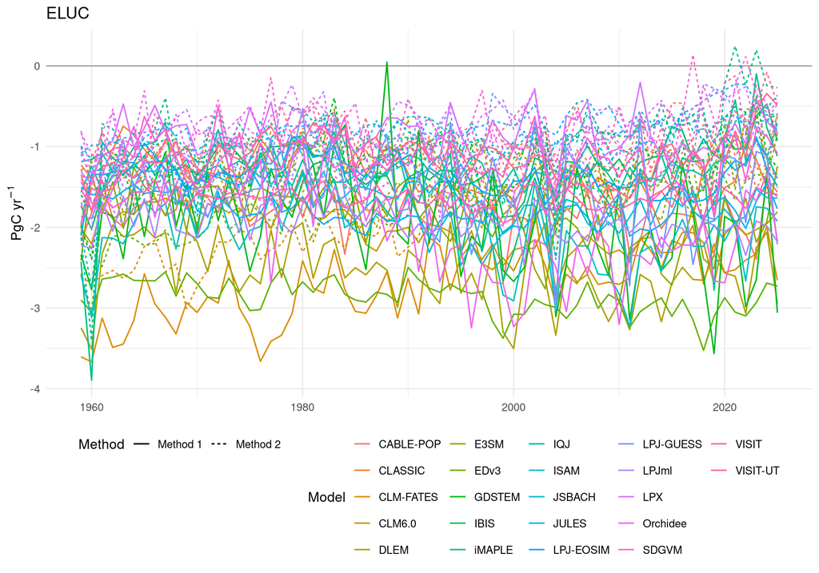

```r
plot_variable("ELUC")
```

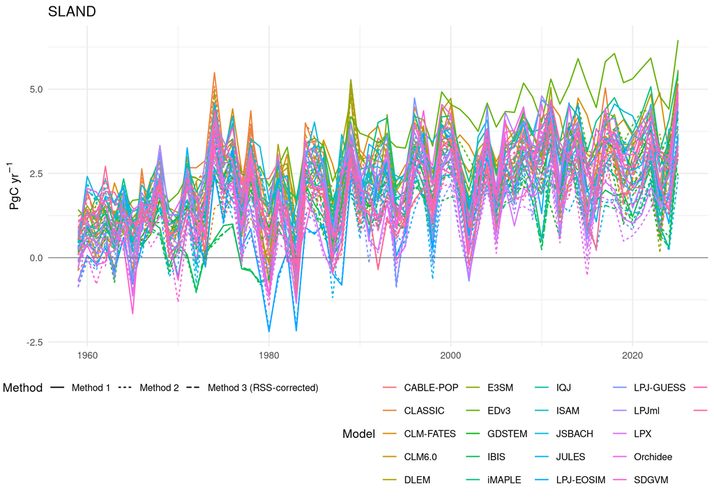

```r
plot_variable("SLAND")
```

## 5b. Time series - one panel per model (Method 1 vs Method 2, plus Method 3 for SLAND)

The plots above overlay every model in one panel, which gets crowded. These faceted versions give each model its own panel, so the methods are easy to compare directly. For SLAND, a model’s panel will show a third (Method 3, RSS-corrected) line if that model has delivered the RSS correction.

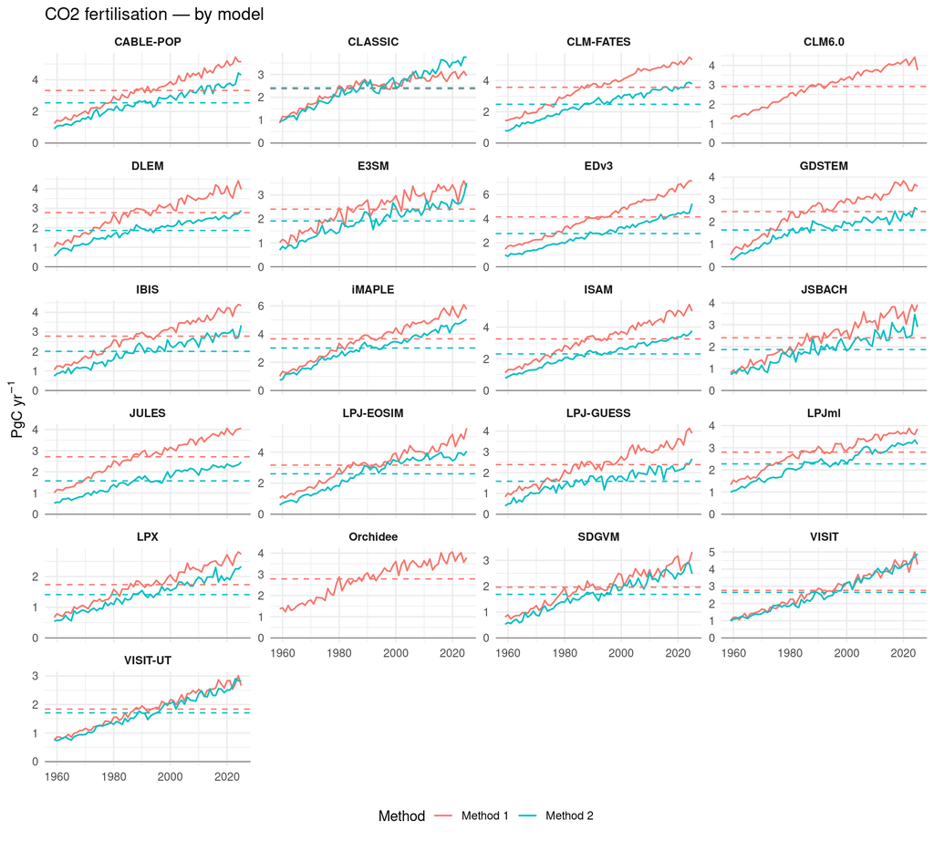

```r
plot_variable_faceted <- function(var_name) {
  d <- extended_long |> filter(Variable == var_name & Year >= start_plot)

  d_mean <- d %>%
    group_by(Model,Method) %>%
    summarise(Mean = mean(Value, na.rm = T), .groups = "drop")

  n_models_here <- n_distinct(d$Model)

  ggplot(d, aes(x = Year, y = Value, colour = Method)) +
    geom_line(linewidth = 0.6) +
    geom_hline(yintercept = 0, colour = "grey40", linewidth = 0.3) +
    geom_hline(data = d_mean, aes(yintercept = Mean, color = Method),
               linetype = "dashed") +
    facet_wrap(~Model, scales = "free_y",
               ncol = if (n_models_here > 6) 4 else 3) +
    labs(title = paste(var_name, "— by model"),
         y = expression(PgC~yr^-1), x = NULL, colour = "Method") +
    theme_minimal(base_size = 11) +
    theme(legend.position = "bottom",
          strip.text = element_text(face = "bold"))
}

plot_variable_faceted("CO2 fertilisation")
```

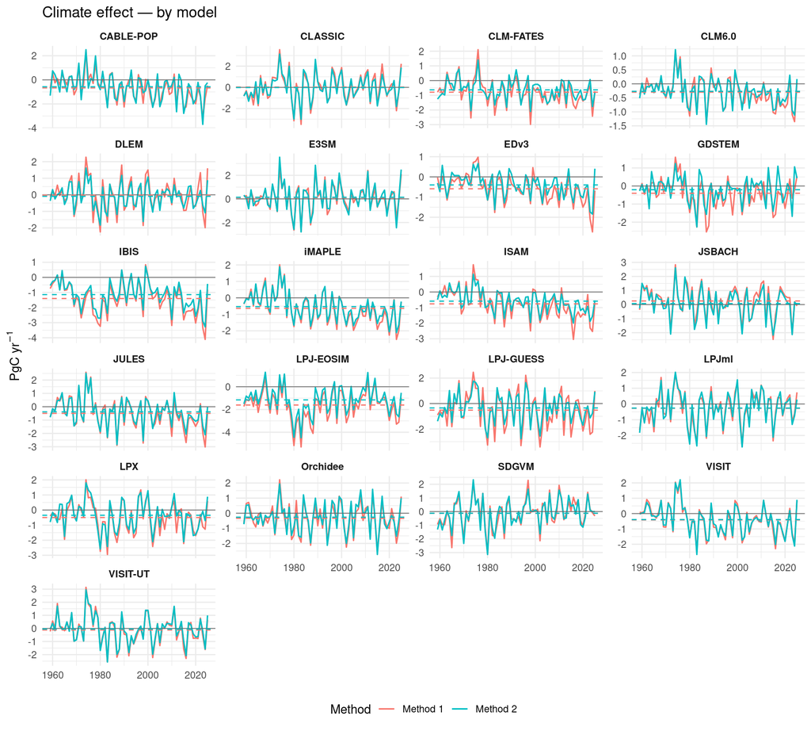

```r
plot_variable_faceted("Climate effect")
```

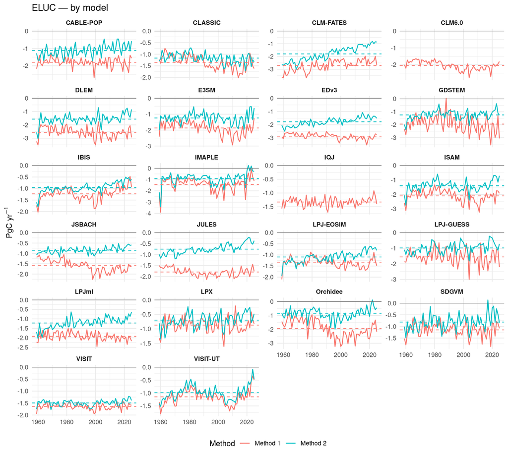

```r
plot_variable_faceted("ELUC")
```

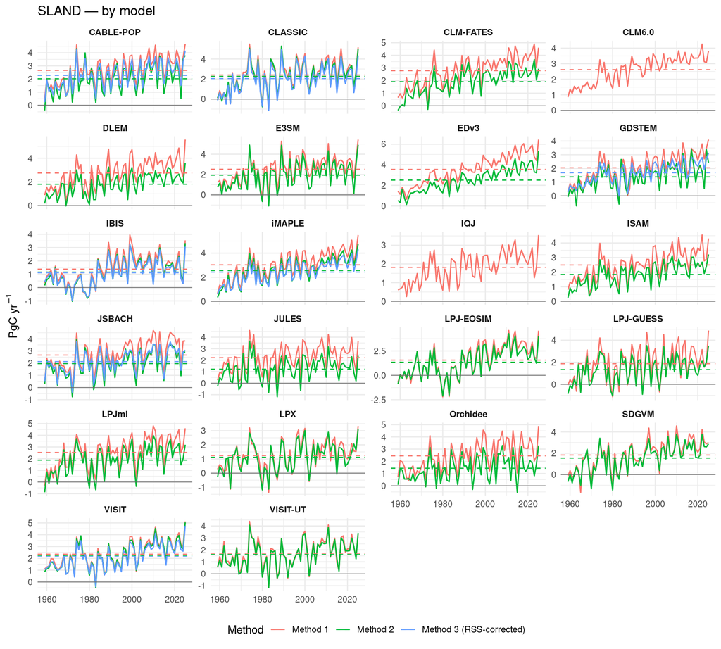

```r
plot_variable_faceted("SLAND")
```

# 6. Multi-model mean time series (Method 1 vs Method 2)

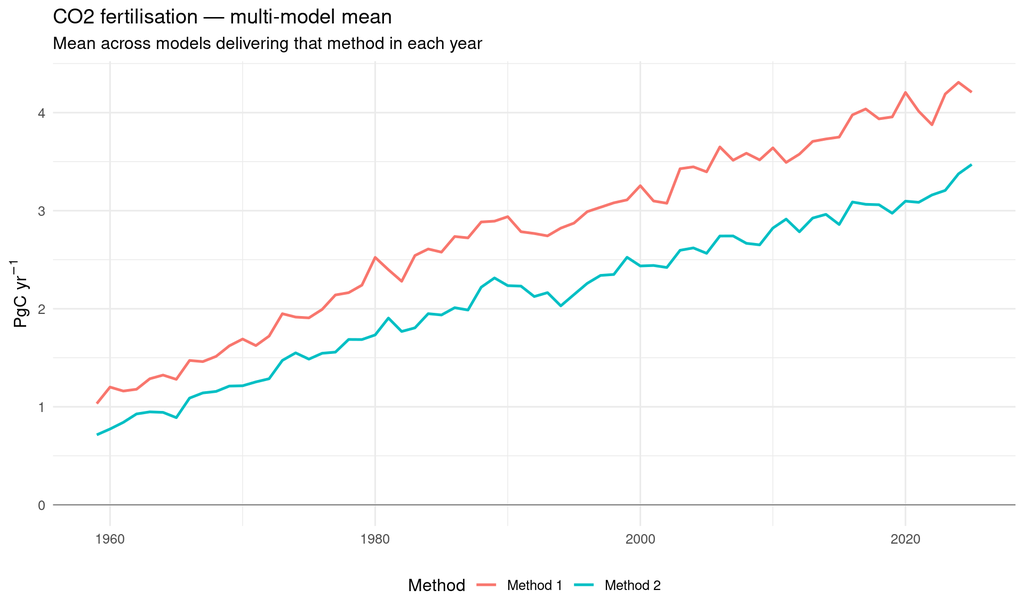

```r
mmm <- derived_long |>
  group_by(Year, Variable, Method) |>
  summarise(
    Value = mean(Value, na.rm = TRUE),
    n_models = n(),
    .groups = "drop"
  )

plot_mmm <- function(var_name) {
  d <- mmm |> filter(Variable == var_name & Year >= start_plot)

  ggplot(d, aes(x = Year, y = Value, colour = Method)) +
    geom_line(linewidth = 0.9) +
    geom_hline(yintercept = 0, colour = "grey40", linewidth = 0.3) +
    labs(title = paste(var_name, "— multi-model mean"),
         subtitle = "Mean across models delivering that method in each year",
         y = expression(PgC~yr^-1), x = NULL, colour = "Method") +
    theme_minimal(base_size = 12) +
    theme(legend.position = "bottom")
}

plot_mmm("CO2 fertilisation")
```

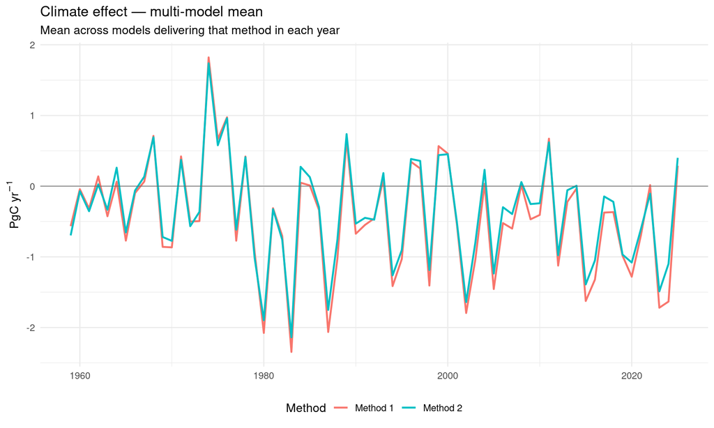

```r
plot_mmm("Climate effect")
```

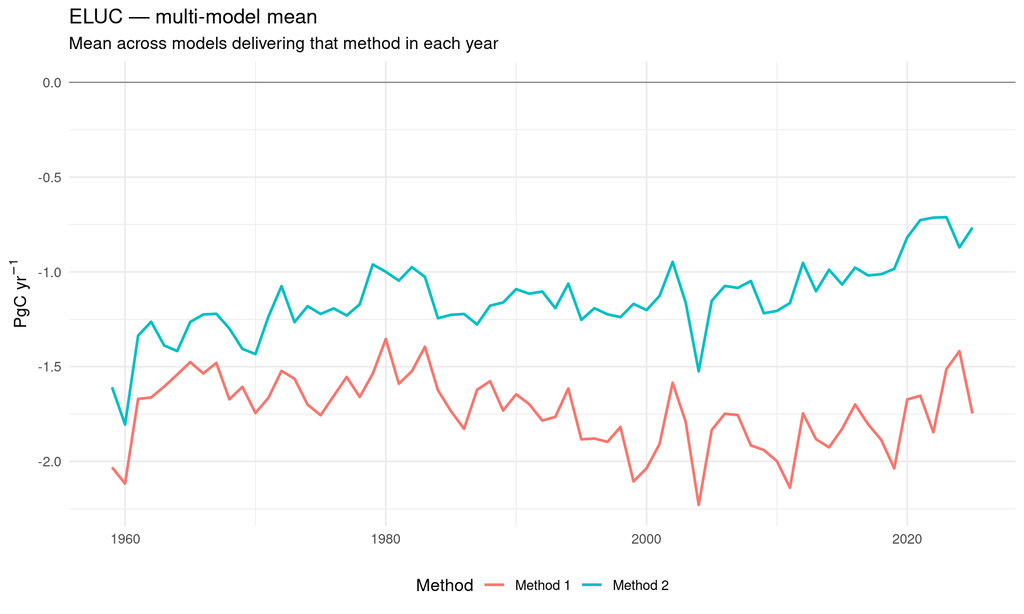

```r
plot_mmm("ELUC")
```

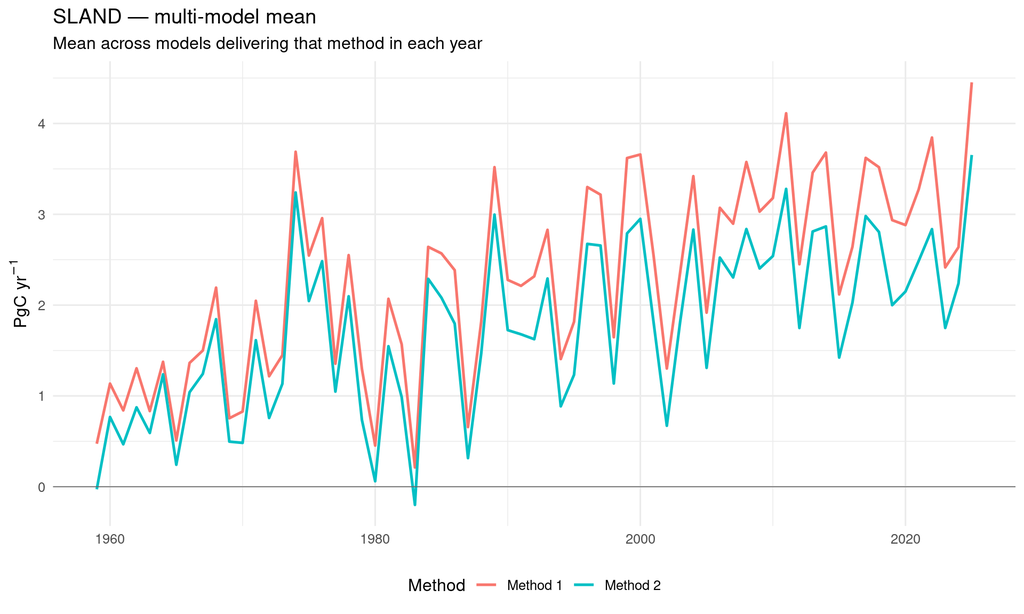

```r
plot_mmm("SLAND")
```

Note: SLAND here uses only Methods 1 and 2 (`derived_long`), not the RSS-corrected Method 3 - so this multi-model mean stays comparable across all contributing models rather than being skewed by the small subset that currently deliver an RSS correction.

# 7. Decadal summary table (multi-model mean)

```r
assign_period <- function(year) {
  case_when(
    year >= 1960 & year <= 1969 ~ "1960s",
    year >= 1970 & year <= 1979 ~ "1970s",
    year >= 1980 & year <= 1989 ~ "1980s",
    year >= 1990 & year <= 1999 ~ "1990s",
    year >= 2000 & year <= 2009 ~ "2000s",
    year >= 2010 & year <= 2019 ~ "2010s",
    year >= 2016 & year <= 2025 ~ "2016-2025",
    TRUE ~ NA_character_
  )
}

period_levels <- c("1960s", "1970s", "1980s", "1990s",
                    "2000s", "2010s", "2016-2025")

# Note: 2016-2025 overlaps with 2010s by design (matches the requested
# periods), so a year like 2018 is counted in both "2010s" and
# "2016-2025". We build this with a join on multiple period labels
# per year rather than a single case_when, to allow the overlap.
year_periods <- tibble(Year = 1960:2025) |>
  mutate(period_10s = if_else(Year >= 2010 & Year <= 2019, "2010s", NA_character_),
         period_decade = case_when(
           Year >= 1960 & Year <= 1969 ~ "1960s",
           Year >= 1970 & Year <= 1979 ~ "1970s",
           Year >= 1980 & Year <= 1989 ~ "1980s",
           Year >= 1990 & Year <= 1999 ~ "1990s",
           Year >= 2000 & Year <= 2009 ~ "2000s",
           TRUE ~ NA_character_
         ),
         period_recent = if_else(Year >= 2016 & Year <= 2025, "2016-2025", NA_character_)) |>
  pivot_longer(starts_with("period"), values_to = "Period", values_drop_na = TRUE) |>
  select(Year, Period)

# Spread across models requires each model's OWN decadal mean first -
# mmm has already collapsed across models, so we go back to
# derived_long (the pre-multi-model-mean data) rather than mmm.
model_decadal <- derived_long |>
  inner_join(year_periods, by = "Year", relationship = "many-to-many") |>
  group_by(Variable, Method, Period, Model) |>
  summarise(Model_Mean = mean(Value, na.rm = TRUE), .groups = "drop")

decadal <- model_decadal |>
  group_by(Variable, Method, Period) |>
  summarise(
    Mean = mean(Model_Mean, na.rm = TRUE),
    SD = sd(Model_Mean, na.rm = TRUE),
    n_models = sum(!is.na(Model_Mean)),
    .groups = "drop"
  ) |>
  mutate(Period = factor(Period, levels = period_levels)) |>
  arrange(Variable, Method, Period)

decadal_table <- decadal |>
  mutate(cell = if_else(n_models >= 2,
                         sprintf("%.2f +/- %.2f", Mean, SD),
                         sprintf("%.2f (n=1)", Mean))) |>
  select(Variable, Method, Period, cell) |>
  pivot_wider(names_from = Period, values_from = cell) |>
  arrange(Variable, Method)

row_group_sizes <- rle(decadal_table$Variable)
pack_index <- setNames(row_group_sizes$lengths, row_group_sizes$values)

decadal_table |>
  kable(caption = "Decadal mean multi-model mean +/- 1 sigma across models (PgC/yr)") |>
  kable_styling(full_width = FALSE) |>
  pack_rows(index = pack_index)
```

Decadal mean multi-model mean +/- 1 sigma across models (PgC/yr)

| Variable | Method | 1960s | 1970s | 1980s | 1990s | 2000s | 2010s | 2016-2025 |
| --- | --- | --- | --- | --- | --- | --- | --- | --- |
| **CO2 fertilisation** |  |  |  |  |  |  |  |  |
| CO2 fertilisation | Method 1 | 1.35 +/- 0.27 | 1.93 +/- 0.38 | 2.62 +/- 0.53 | 2.91 +/- 0.63 | 3.40 +/- 0.77 | 3.78 +/- 0.90 | 4.07 +/- 1.02 |
| CO2 fertilisation | Method 2 | 0.99 +/- 0.22 | 1.47 +/- 0.31 | 1.96 +/- 0.41 | 2.24 +/- 0.51 | 2.59 +/- 0.60 | 2.95 +/- 0.72 | 3.16 +/- 0.79 |
| **Climate effect** |  |  |  |  |  |  |  |  |
| Climate effect | Method 1 | -0.15 +/- 0.35 | 0.07 +/- 0.61 | -0.81 +/- 0.65 | -0.43 +/- 0.44 | -0.59 +/- 0.47 | -0.58 +/- 0.60 | -0.81 +/- 0.72 |
| Climate effect | Method 2 | -0.11 +/- 0.25 | 0.07 +/- 0.52 | -0.68 +/- 0.49 | -0.34 +/- 0.33 | -0.44 +/- 0.35 | -0.44 +/- 0.44 | -0.64 +/- 0.55 |
| **ELUC** |  |  |  |  |  |  |  |  |
| ELUC | Method 1 | -1.64 +/- 0.54 | -1.64 +/- 0.55 | -1.60 +/- 0.54 | -1.81 +/- 0.50 | -1.87 +/- 0.55 | -1.89 +/- 0.55 | -1.73 +/- 0.57 |
| ELUC | Method 2 | -1.36 +/- 0.43 | -1.20 +/- 0.40 | -1.14 +/- 0.37 | -1.16 +/- 0.31 | -1.15 +/- 0.30 | -1.05 +/- 0.32 | -0.86 +/- 0.33 |
| **SLAND** |  |  |  |  |  |  |  |  |
| SLAND | Method 1 | 1.18 +/- 0.39 | 1.99 +/- 0.62 | 1.79 +/- 0.74 | 2.46 +/- 0.58 | 2.78 +/- 0.63 | 3.17 +/- 0.72 | 3.22 +/- 0.81 |
| SLAND | Method 2 | 0.88 +/- 0.29 | 1.56 +/- 0.58 | 1.33 +/- 0.57 | 1.87 +/- 0.44 | 2.15 +/- 0.45 | 2.45 +/- 0.62 | 2.49 +/- 0.67 |

## 7.1 Decadal summary for RSS-delivering models only (3 methods)

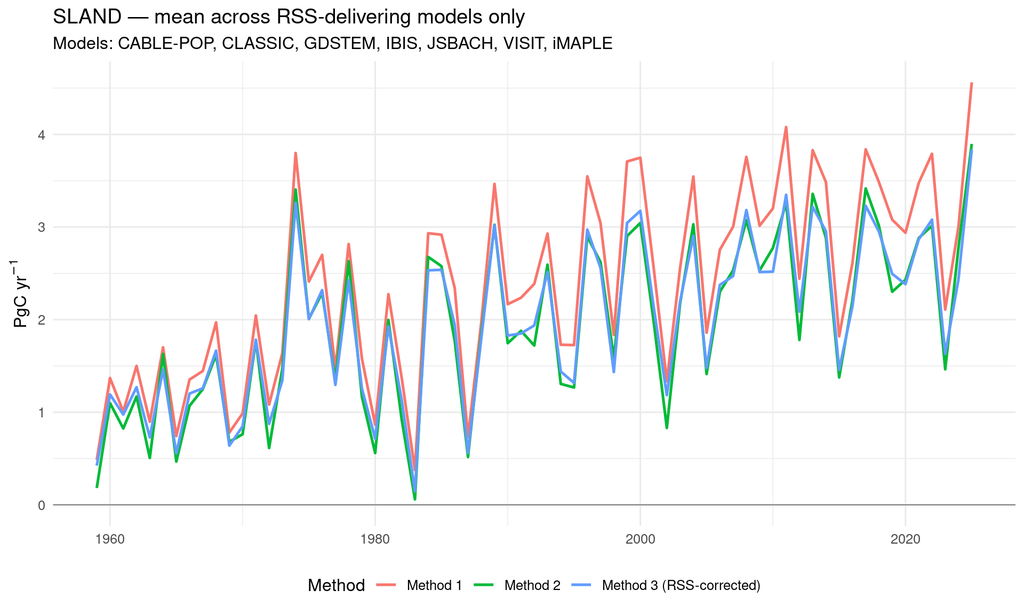

```r
mmm_rss <- extended_long |>
  filter(Variable == "SLAND", Model %in% rss_models) |>
  group_by(Year, Method) |>
  summarise(
    Value = mean(Value, na.rm = TRUE),
    n_models = n(),
    .groups = "drop"
  )

ggplot(mmm_rss |> filter(Year >= start_plot), aes(x = Year, y = Value, colour = Method)) +
  geom_line(linewidth = 0.9) +
  geom_hline(yintercept = 0, colour = "grey40", linewidth = 0.3) +
  labs(title = "SLAND — mean across RSS-delivering models only",
       subtitle = sprintf("Models: %s", paste(rss_models, collapse = ", ")),
       y = expression(PgC~yr^-1), x = NULL, colour = "Method") +
  theme_minimal(base_size = 12) +
  theme(legend.position = "bottom")
```

```r
decadal_rss <- mmm_rss |>
  inner_join(year_periods, by = "Year", relationship = "many-to-many") |>
  group_by(Method, Period) |>
  summarise(Mean = mean(Value, na.rm = TRUE), .groups = "drop") |>
  mutate(Period = factor(Period, levels = period_levels)) |>
  arrange(Method, Period)

decadal_table_rss <- decadal_rss |>
  pivot_wider(names_from = Period, values_from = Mean) |>
  arrange(Method)

decadal_table_rss |>
  mutate(across(where(is.numeric), ~round(.x, 2))) |>
  kable(caption = sprintf("SLAND decadal mean (PgC/yr), RSS-delivering models only (n = %d): %s",
                           length(rss_models), paste(rss_models, collapse = ", "))) |>
  kable_styling(full_width = FALSE)
```

SLAND decadal mean (PgC/yr), RSS-delivering models only (n = 7): CABLE-POP, CLASSIC, GDSTEM, IBIS, JSBACH, VISIT, iMAPLE

| Method | 1960s | 1970s | 1980s | 1990s | 2000s | 2010s | 2016-2025 |
| --- | --- | --- | --- | --- | --- | --- | --- |
| Method 1 | 1.28 | 2.05 | 1.92 | 2.53 | 2.81 | 3.19 | 3.29 |
| Method 2 | 1.03 | 1.75 | 1.59 | 2.05 | 2.29 | 2.64 | 2.74 |
| Method 3 (RSS-corrected) | 1.10 | 1.74 | 1.63 | 2.09 | 2.36 | 2.64 | 2.71 |